# Species Distribution Models

# Species Distribution Modelling

## Background

This vignette details the steps required to create a Species Distribution Model (SDM) using the functions provided in `safeHavens`. The SDM is required to use the `EnvironmentalBasedSample` function, which is the most complex sampling scheme provided in the package. The SDM is created using an elastic net generalized linear model implemented via the `glmnet` package. The SDM is then post-processed to create a binary raster map of suitable and unsuitable habitat, that is used to rescale the environmental predictor variables according to their contributions to the model. These rescaled variables are then used in a clustering algorithm to partition the species range into environmentally distinct regions for germplasm sampling.

The goal of most SDM’s is to create a model that accurately predicts where a species will be located in environmental space and can then be predicted in geographic space. The goal of these models is to understand the degree and direction to which various environmental features correlate with a species observed range. This model is not intended to replace a well-structured and thought-out SDM; rather, it is intended to provide a quick model that can be used to inform sampling strategies.

## About

While the authors are prone to creating many ‘advanced’ SDMs models and in-house pipelines for developing them, we think that the juice is not worth the squeeze and rely on a few powerhouse R packages to do the heavy lifting. The main packages used are `dismo`, `caret`, `glmnet`, `CAST`, and `terra`. The `dismo` package provides a user-friendly interface for working with species occurrence and raster data, as well as some helper functions for thresholding and evaluating models. The `caret` package provides a nice interface for working with machine learning models, and the `glmnet` package provides the elastic net model. The `CAST` package provides functions for spatially informed cross-validation, which is important for SDMs. The `terra` package provides functions for working with raster data. All of these packages are well documented, and maintained.

# Steps to create an SDM

### prep data

```r
library(safeHavens)
```

First you will need georeference occurrence data for your species of interest. For common species we recommened the `rgbif` package to download occurrence data from GBIF.

Here to maintain a smaller package size, and integrate with the tutorial in `dismo` we use a built in data set for *Bradypus variegatus* (Brown-throated sloth). We do this to also leverage the raster data provided in `dismo` as well.

```r
x <- read.csv(file.path(system.file(package="dismo"), 'ex', 'bradypus.csv'))
x <- x[,c('lon', 'lat')]
x <- sf::st_as_sf(x, coords = c('lon', 'lat'), crs = 4326)

planar_proj <- 3857 # Web Mercator for planar distance calcs

files <- list.files(
  path = file.path(system.file(package="dismo"), 'ex'),
  pattern = 'grd',  full.names=TRUE )
predictors <- terra::rast(files) # import the independent variables
```

## fit the model

Here we fit as SDM using `elasticSDM`. For arguments it requires occurrence data `x`, a raster stack of `predictors`, a `quantile_v` that is an offset used to create pseudo-absence data, and a `planar_proj` used to calculate distances between occurrence data and possible pseudo-absence points. The `quantile_v` is used to create pseudo-absence data by calculating the distance from each occurrence point to the nearest neighbor, and then selecting a quantile of these distances to create a buffer around each occurrence point. Points outside of this buffer are used pseudo-absences.

```r
sdModel <- elasticSDM(
  x = x,
  predictors = predictors,
  quantile_v = 0.025,
  planar_proj = planar_proj
  )
```

Under the hood this function uses `caret` to help out with `glmnet`, as it provides output which is very easy to explore and interact with. Elastic net modelS bridge the world of lasso and ridge regression by blending the alpha parameter. Lasso has an alpha of 0, while Ridge has an alpha of 1. Lasso regression will perform automated variable selection, and can drop (or ‘shrink’) features from a model, whereas Ridge will keep all variables and if correlated features exist split contributions between them. An elastic net blends this propensity to drop or retain variables whenever it is used. `caret` will test a range of alphas to determine how much ridge or lasso regression characteristics are best for the data at hand.

### explore the output

```r
sdModel$ConfusionMatrix
Confusion Matrix and Statistics

          Reference
Prediction  0  1
         0 20  1
         1  3 21

               Accuracy : 0.9111
                 95% CI : (0.7878, 0.9752)
    No Information Rate : 0.5111
    P-Value [Acc > NIR] : 1.055e-08

                  Kappa : 0.8225

 Mcnemar's Test P-Value : 0.6171

            Sensitivity : 0.9545
            Specificity : 0.8696
         Pos Pred Value : 0.8750
         Neg Pred Value : 0.9524
             Prevalence : 0.4889
         Detection Rate : 0.4667
   Detection Prevalence : 0.5333
      Balanced Accuracy : 0.9121

       'Positive' Class : 1
```

### binarize the output

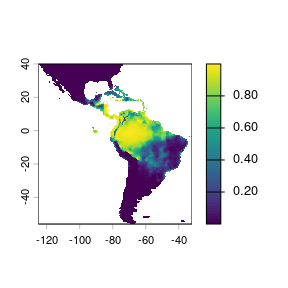

```r
terra::plot(sdModel$RasterPredictions)
```

SDM’s produce continuous surfaces displaying the predicted probability of suitable habitat across a landscape. However binary surfaes (Yes/No Suitable), i.e. *is it more or less probable that suitable habitat for this taxon exists in this particular location (grid cell)?* are often required from them; the function `PostProcessSDM` is used to binarize the predictions.

Going from a continuous surface to a binary surface loses information. The goal of the binary surface is to understand where the species is likely to be found, and then sample germplasm from these areas. There are many ways to threshold a SDM, and many caveats associated with this process; Frank Harrell has written on the topic of post-processing in statistics.

Historically, when assessing probability output 0.5 probability was used as a threshold, probabilities beneath it considered ‘Not Suitable / No’, while probabilities above are classified as ‘Suitable / Yes’. This works for some cases, but thresholding is outside the domain of statistics and in the realm of practice. My motto for implementing models, is a slight elaboration of George Box’s aphorism, “*All models are wrong, some are useful - how do you want to be wrong?*”. Our goal of sampling for germplasm conservation is to maximize the representation of allelic diversity across the range of a species. To achieve this, we need an understanding of the species actual range, hence it is better to predict the species present where it is not, than to predict it absent where it actually grows. Accordingly, my default thresholding statistic is *Sensitivity*. However, our function supports all threshold options in `dismo::threshold`.

You may be wondering why this function is named `PostProcessSDM` rather `ThresholdSDM`, the reason for this discontinuity is that the function performs additional processes after thresholding. Geographic buffers are created around the intitial occurence points to ensure that none of the known occurrence points are ‘missing’ from the output binary map. This is a two edged sword, where we are again address the notion of dispersal limitation, and realize that not all suitable habitat is occupied habitat.

```r
threshold_rasts <- PostProcessSDM(
  rast_cont = sdModel$RasterPredictions,
  test = sdModel$TestData,
  train = sdModel$TrainData,
  planar_proj = planar_proj,
  thresh_metric = 'sensitivity',
  quant_amt = 0.5
  )
```

We can compare the results of applying this function side by side using the output from the function.

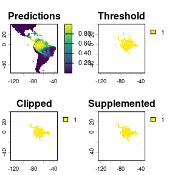

```r
terra::plot(threshold_rasts$FinalRasters)
```

### rescale predictor variables

`glmnet` is used for three main reasons, 1) it gives directional coefficients and documents how each 1 unit increase in an independent variable varies the response. 2) It maintains automated feature selection reducing the work an analyst needs to do. 3) `glmnet` re-scales all variables before model generation combined with beta-coefficients allows for partitioning environmental space into regions that are environmentally similar *for the individual species*.

In this way our raster stack becomes representative of our model, we can then use these values as the basis for hierarchical cluster later on.

Below we create a copy of the raster predictions where we have standardized each variable, so it is equivalent to the input to glmnet, and then mulitplied by its beta-coefficient. We will also write out these beta coefficients with the `writeSDMresults` function right afterwards.

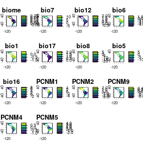

```r
rr <- RescaleRasters(
  model = sdModel$Model,
  predictors = sdModel$Predictors,
  training_data = sdModel$TrainData,
  pred_mat = sdModel$PredictMatrix)

terra::plot(rr$RescaledPredictors)
```

We can see that the variables are ‘close’ to being on the same scale, this will work in a clustering algorithm. If any of the layers are all the same color (maybe yellow?) that means they have no variance, that’s a term that was shrunk from the model. It will be dealt with internally in a future function. The scales of the variables are not exact, because they are weighed by their coefficients in the model

`safeHavens` generates all kinds of things as it runs through the functions `elasticSDM`, `PostProcessSDM`, and `RescaleRasters`. Given that one of these sampling scheme may be followed for quite some time, it is best practice to save many of these objects.

### save results

```r
bp <- '~/Documents/assoRted/StrategizingGermplasmCollections'

writeSDMresults(
  cv_model = sdModel$CVStructure,
  pcnm = sdModel$PCNM,
  model = sdModel$Model,
  cm = sdModel$ConfusionMatrix,
  coef_tab = rr$BetaCoefficients,
  f_rasts = threshold_rasts$FinalRasters,
  thresh = threshold_rasts$Threshold,
  file.path(bp, 'results', 'SDM'), 'Bradypus_test')

# we can see that the files were placed here using this.
list.files( file.path(bp, 'results', 'SDM'), recursive = TRUE )
```

[output not shown]

### wrapping up

And there you have it, all the steps to make a species distribution model - or rather to get the coefficients from a species distribution model! We will play around with it as an example data set to compare our buffered distance results to at the end - head over to the next vignette!